# WHIRL_Usage

```r
# devtools::build_rmd("vignettes/WHIRL_Usage.Rmd")
# library(devtools)
# library(ggplot2)
# load_all()
library(WHIRL)
data("processed_hurdat")
```

## Analysis Q1: Plot tracks of storm in 2020, 2021, 2022.

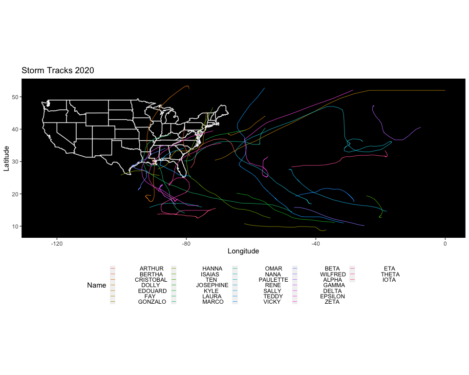

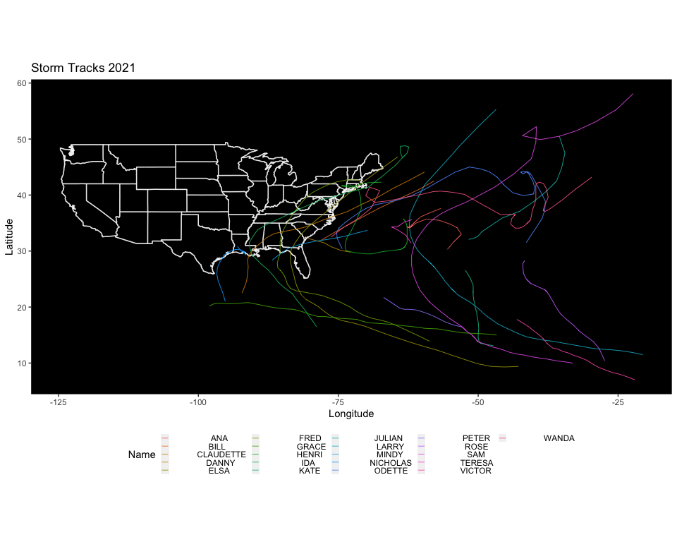

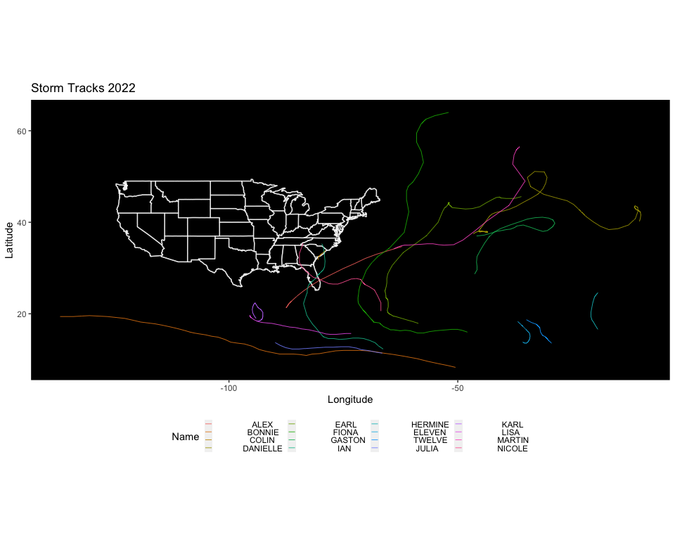

```r
# plot storm's track

get_stormp <- function(processed_hurdat,year){
  idx = grep(paste("^",year,sep=""),processed_hurdat$Date)
  id.year = unique(processed_hurdat[idx,1])
  p <- WHIRL::plot_storm_tracks(processed_hurdat,id.year)
  p <- p + ggplot2::labs(title=paste("Storm Tracks ",year,sep=""))
  return(p)}

for (i in c("2020","2021","2022")){
pi = get_stormp(processed_hurdat,i)
print(pi)}
```

## Analysis Q2: Plot the position and size of Hurricanes Katrina (2005), Sandy (2012), Harvey (2017), and Ian (2022).

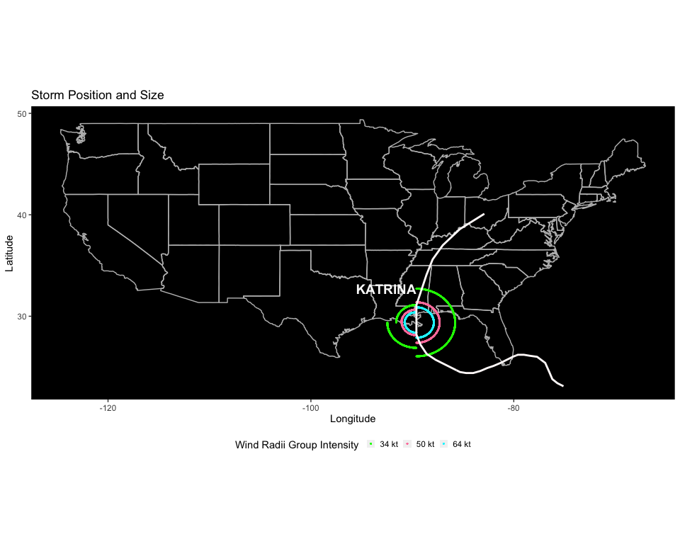

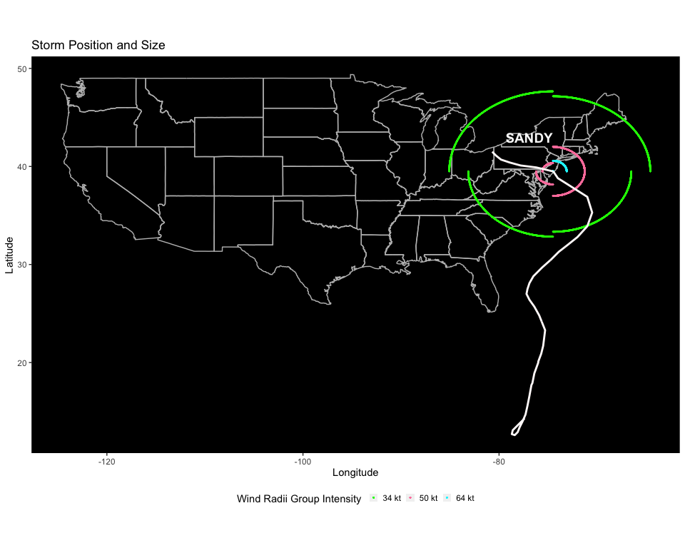

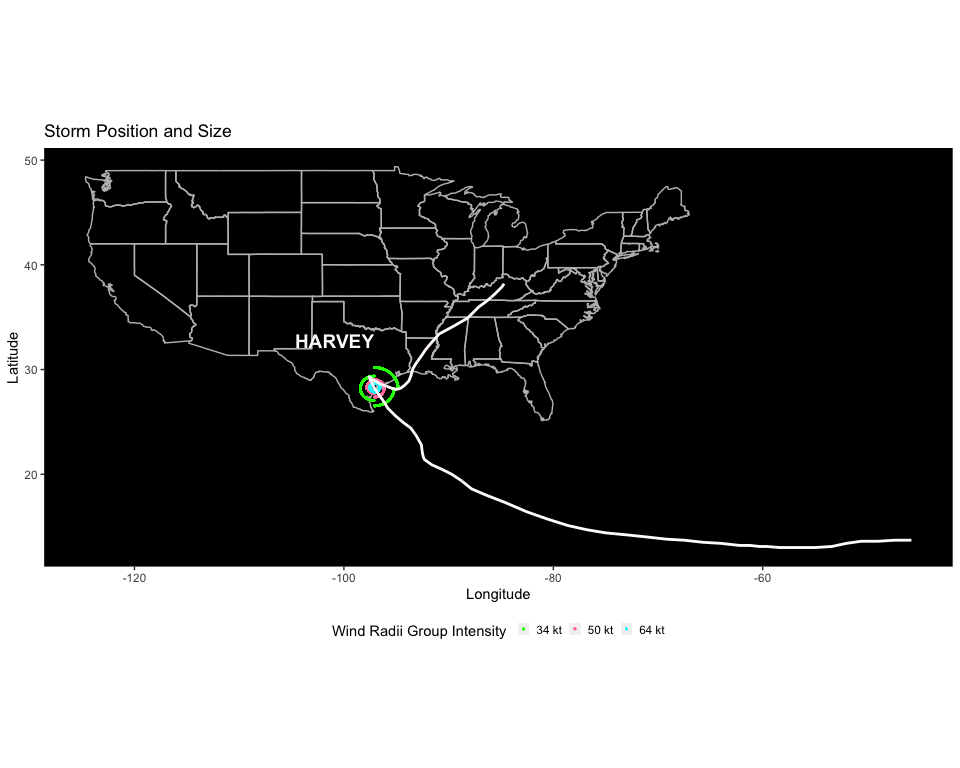

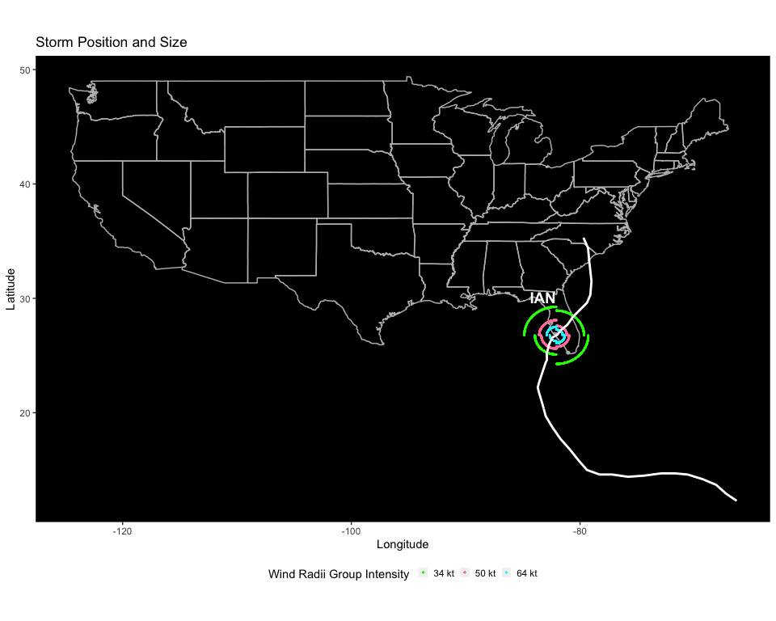

```r
# plot storm's size and range

listQ2 = list(name=c("katrina","sandy","harvey","ian"),
              year=c("2005","2012","2017","2022"))
for (i in 1:length(listQ2$name)) {
  tempi = WHIRL::plot_storm_size_helper(processed_hurdat,
                                        listQ2$name[i],
                                        listQ2$year[i])
  pi = WHIRL::plot_storm_size(tempi[1,],tempi[-1,])
  print(pi)
}
```

## Analysis Q3: Create a new dataframe with storm id, name, maximum wind speed, minimum pressure, indicator for landfall, accumulated cyclone energy.

```r
# get the dataframe df for storm and their relavant information
unique.storm.id = unique(processed_hurdat$ID)

df = data.frame(matrix(nrow = length(unique.storm.id),ncol = 6))
colnames(df) = c("ID","Name","Maximum.Wind","Minimum.Pressure","Landfall","CumE")
df[,1] = unique.storm.id
for (i in 1:nrow(df)){
  storm.id.i = unique.storm.id[i]
  dfi = subset(processed_hurdat,ID == unique.storm.id[i])
  df[i,2:6] = c(
    dfi$Name[1],
    if (all(is.na(dfi$"Maximum.Wind"))) {NA} else     # if all NA then NA
            max(dfi$"Maximum.Wind",na.rm=TRUE),
    if (all(is.na(dfi$"Minimum.Pressure"))) {NA} else # if all NA then NA
              min(dfi$"Minimum.Pressure",na.rm=TRUE),
    if (is.logical(WHIRL::landfall(dfi,storm.id.i))) FALSE else TRUE,
    WHIRL::cumE(dfi,storm.id.i)
  )
}
head(df)
```

```
#>         ID                Name Maximum.Wind Minimum.Pressure Landfall  CumE
#> 1 AL011851             UNNAMED           80             <NA>     TRUE  5.55
#> 2 AL021851             UNNAMED           80             <NA>    FALSE  0.64
#> 3 AL031851             UNNAMED           50             <NA>    FALSE  0.25
#> 4 AL041851             UNNAMED          100             <NA>     TRUE 22.83
#> 5 AL051851             UNNAMED           50             <NA>    FALSE     4
#> 6 AL061851             UNNAMED           60             <NA>     TRUE  4.86
```

## Analysis Q4: Include 2 additional plots.

We found that the most of the maximum sustained speed (>0) of the recorded hurricane is about 30 knots. But that of hurricanes that landed is about 70 knots and 90 knots.

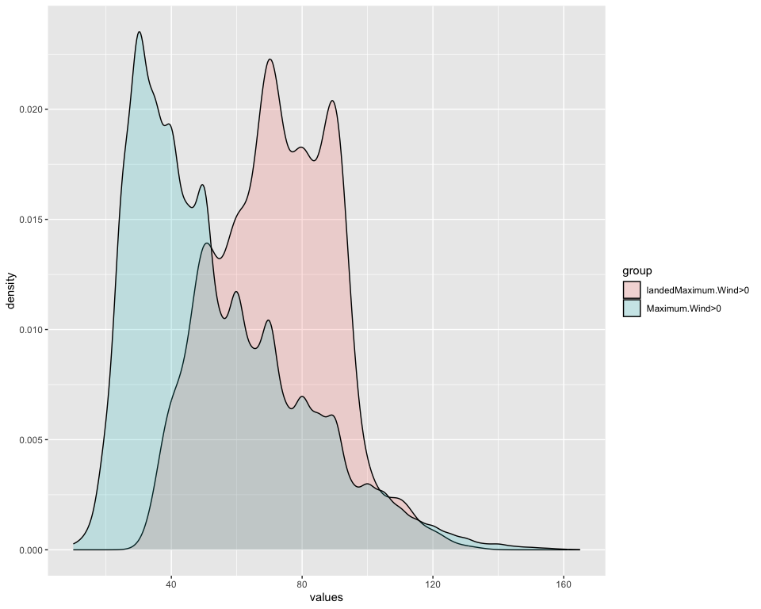

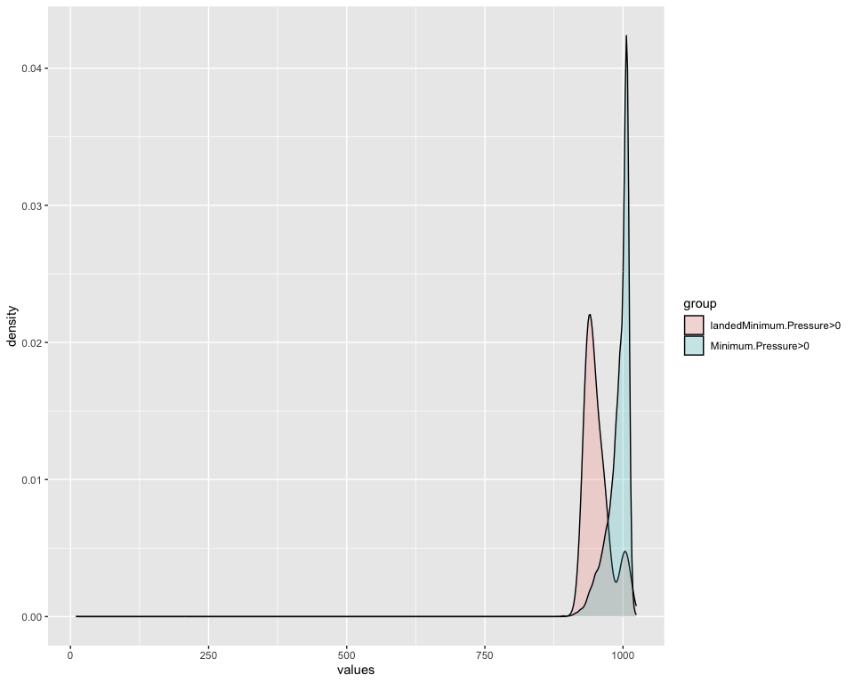

```r
plot_density <- function(dat,coli){
  wind.df = dat[,coli]
  idx.0 = which(wind.df>0)
  wind.df.filtered = as.vector(wind.df[idx.0])
  names(wind.df.filtered) = coli

  # maximum wind with speed >0 and landed
  idx.land = which(df$Landfall==TRUE)
  wind.df.land = as.vector(wind.df[intersect(idx.0,idx.land)]) # the storm that landed
  names(wind.df.land) = paste(coli,"land",sep=".")


  df0 = data.frame(values=c(wind.df.filtered,wind.df.land),
                  group=c(rep(paste(coli,">0",sep=""),
                              length(wind.df.filtered)),
                          rep(paste("landed",coli,">0",sep=""),
                            length(wind.df.land)) )
                    )
  p0 = ggplot2::ggplot(df0, ggplot2::aes(x = values, fill = group)) +
    # Draw overlaying density
    ggplot2::geom_density(position = "identity", alpha = 0.2)
  return(p0)
  }
# maximum wind with speed >0
for (coli in c("Maximum.Wind","Minimum.Pressure")){
  pi = plot_density(processed_hurdat,coli)
  print(pi)
  }
```

## Analysis Q5: Is the number of landfalling hurricanes increasing over time.

```r
hur = processed_hurdat
hur_l = hur[grepl("L",hur$Landfall)==T,]
hur_l$year = as.numeric(format(as.Date(hur_l$Date, format = "%Y%m%d"), "%Y"))
hur_by_year = as.data.frame(table(hur_l$year))
colnames(hur_by_year) = c("Year","Count")
hur_by_year$Year = as.numeric(hur_by_year$Year)
hur_by_year$Year = hur_by_year$Year + 1850
lm = lm(Count ~ Year, data = hur_by_year)
summary(lm)
```

```
#>
#> Call:
#> lm(formula = Count ~ Year, data = hur_by_year)
#>
#> Residuals:
#>     Min      1Q  Median      3Q     Max
#> -9.5563 -3.0556 -0.6035  2.6024 20.4479
#>
#> Coefficients:
#>               Estimate Std. Error t value Pr(>|t|)
#> (Intercept) -153.21406   16.80166  -9.119  3.9e-16 ***
#> Year           0.08322    0.00871   9.554  < 2e-16 ***
#> ---
#> Signif. codes:  0 '***' 0.001 '**' 0.01 '*' 0.05 '.' 0.1 ' ' 1
#>
#> Residual standard error: 4.899 on 154 degrees of freedom
#> Multiple R-squared:  0.3722, Adjusted R-squared:  0.3681
#> F-statistic: 91.28 on 1 and 154 DF,  p-value: < 2.2e-16
```

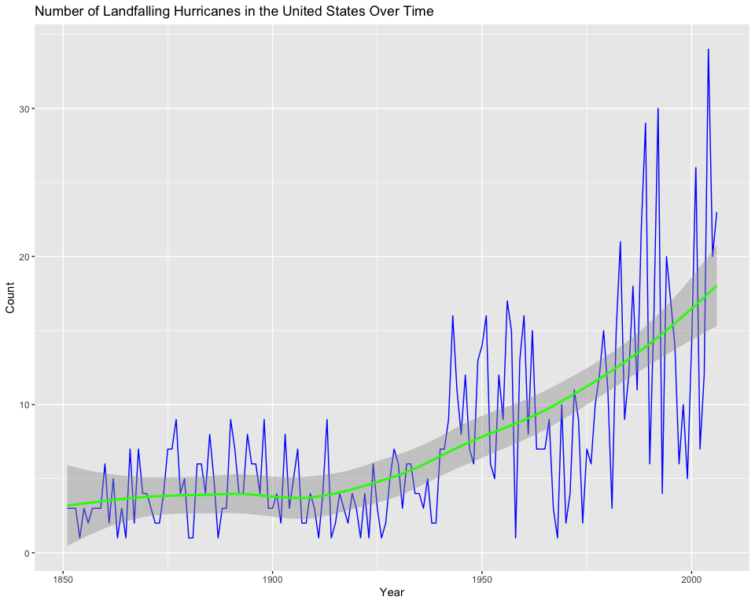

```r
ggplot2::ggplot(hur_by_year,
                ggplot2::aes(x = Year, y = Count)) +
  ggplot2::geom_line(color = "blue") +
  ggplot2::labs(title = "Number of Landfalling Hurricanes in the United States Over Time",
       x = "Year",
       y = "Count")+
  ggplot2::geom_smooth(method = "loess", color = "green")
```

```r
hur_by_year$YearGroup <- cut(hur_by_year$Year, breaks = seq(1850, 2020, by = 5))
hur_by_year$AvgCount <- ave(hur_by_year$Count, hur_by_year$YearGroup, FUN = mean)
hur_by_year = hur_by_year[-c(171,172),]
before = subset(hur_by_year, Year <= 1935)
after = subset(hur_by_year, Year >= 1936)
t.test(before$AvgCount,after$AvgCount, alternative = "le")
```

```
#>
#>  Welch Two Sample t-test
#>
#> data:  before$AvgCount and after$AvgCount
#> t = -12.663, df = 74.841, p-value < 2.2e-16
#> alternative hypothesis: true difference in means is less than 0
#> 95 percent confidence interval:
#>       -Inf -6.193458
#> sample estimates:
#> mean of x mean of y
#>  4.023529 11.154930
```

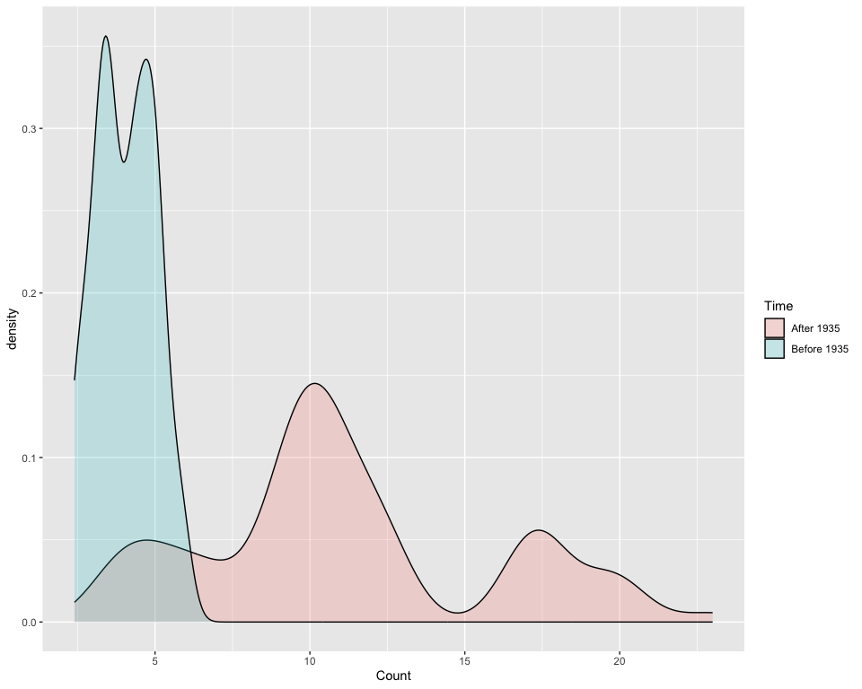

```r
hur_bf_af = data.frame(Count = c(before$AvgCount, after$AvgCount),
                         Time = c(rep("Before 1935", length(before$AvgCount)),
                                   rep("After 1935", length(after$AvgCount)))
)
ggplot2::ggplot(hur_bf_af,
                ggplot2::aes(x = Count, fill = Time)) +
  ggplot2::geom_density(position = "identity", alpha = 0.2)
```

Based on the analysis, it appears that the number of landfalling hurricanes in the United States has been increasing over time. The linear regression model shows a statistically significant positive relationship between the number of landfalling hurricanes and year, with an estimated increase of 0.08 hurricanes per year (p < 2.2e-16).

The graph of the number of landfalling hurricanes over time also shows an increasing trend, with some fluctuations over the years.

Additionally, the t-test comparing the average number of landfalling hurricanes before and after 1935 shows a statistically significant difference, with an average of 4.02 hurricanes before 1935 and 11.15 hurricanes after 1935 (t = -12.663, df = 74.841, p-value < 2.2e-16). The density plot also shows that the distribution of landfalling hurricanes after 1935 is shifted to the right compared to before 1935.

Therefore, the analysis suggests that the number of landfalling hurricanes in the United States has been increasing over time.

## Analysis Q6: Is the intensity of tropical cyclones increasing over time?

```r
speed = processed_hurdat
speed$year = as.numeric(format(as.Date(speed$Date, format = "%Y%m%d"), "%Y"))
speed_by_year = as.data.frame(table(speed$year))
colnames(speed_by_year) = c("Year","Speed")
speed_by_year$Year = as.numeric(speed_by_year$Year)
speed_by_year$Year = speed_by_year$Year + 1850
speed_by_year = subset(speed_by_year, Speed >= 0)
lm = lm(Speed ~ Year, data = speed_by_year)
summary(lm)
```

```
#>
#> Call:
#> lm(formula = Speed ~ Year, data = speed_by_year)
#>
#> Residuals:
#>     Min      1Q  Median      3Q     Max
#> -290.34  -73.54  -17.15   66.93  428.90
#>
#> Coefficients:
#>               Estimate Std. Error t value Pr(>|t|)
#> (Intercept) -4330.1884   381.7210  -11.34   <2e-16 ***
#> Year            2.3981     0.1971   12.17   <2e-16 ***
#> ---
#> Signif. codes:  0 '***' 0.001 '**' 0.01 '*' 0.05 '.' 0.1 ' ' 1
#>
#> Residual standard error: 128.3 on 170 degrees of freedom
#> Multiple R-squared:  0.4656, Adjusted R-squared:  0.4624
#> F-statistic: 148.1 on 1 and 170 DF,  p-value: < 2.2e-16
```

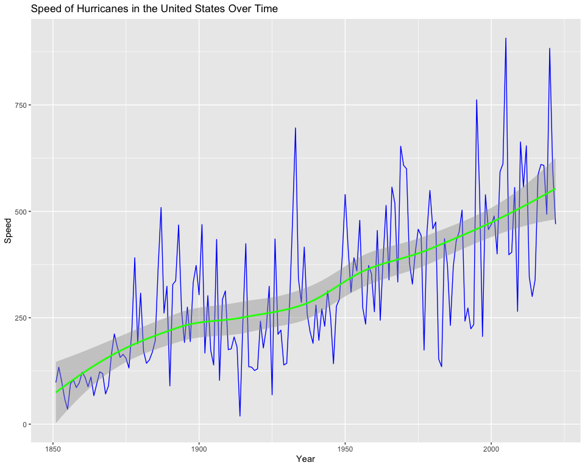

```r
ggplot2::ggplot(speed_by_year,
                ggplot2::aes(x = Year, y = Speed)) +
 ggplot2::geom_line(color = "blue") +
  ggplot2::labs(title = "Speed of Hurricanes in the United States Over Time",
       x = "Year",
       y = "Speed")+
  ggplot2::geom_smooth(method = "loess", color = "green")
```

```r
speed_by_year$YearGroup <- cut(speed_by_year$Year, breaks = seq(1850, 2020, by = 5))
speed_by_year$AvgSpeed <- ave(speed_by_year$Speed, speed_by_year$YearGroup, FUN = mean)
speed_by_year = speed_by_year[-c(171,172),]
before = subset(speed_by_year, Year <= 1935)
after = subset(speed_by_year, Year >= 1936)
t.test(unique(before$AvgSpeed),unique(after$AvgSpeed), alternative = "le")
```

```
#>
#>  Welch Two Sample t-test
#>
#> data:  unique(before$AvgSpeed) and unique(after$AvgSpeed)
#> t = -5.7124, df = 31.244, p-value = 1.356e-06
#> alternative hypothesis: true difference in means is less than 0
#> 95 percent confidence interval:
#>       -Inf -137.4253
#> sample estimates:
#> mean of x mean of y
#>  213.5059  408.9176
```

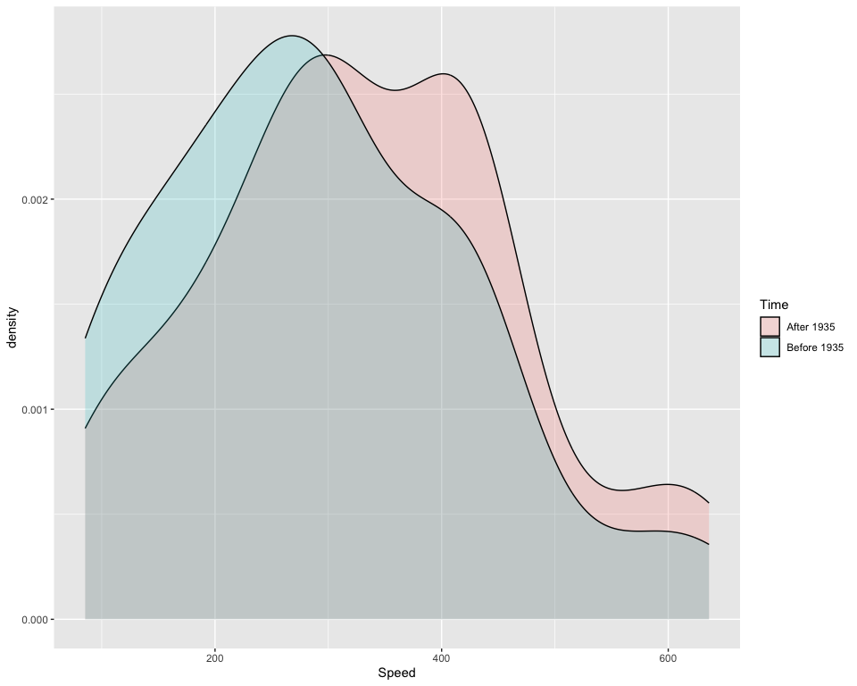

```r
speed_bf_af = data.frame(Speed = c(unique(before$AvgSpeed), unique(after$AvgSpeed)),
                         Time = c(rep("Before 1935", length(before$AvgSpeed)),
                                   rep("After 1935", length(after$AvgSpeed)))
)
ggplot2::ggplot(speed_bf_af,
                ggplot2::aes(x = Speed, fill = Time)) +
  ggplot2::geom_density(position = "identity", alpha = 0.2)
```

## Analysis Q7: Find a claim made in the media made about tropical cyclones and climate change. Check what ChatGPT has to say about the claim.

I found a news from [CNN](http://www.cnn.com/SPECIALS/2005/katrina/) about Hurricane Katrina 2005.

*Voices from the Gulf Coast:*

August 29, 2005: Hurricane Katrina made landfall on the Gulf Coast, destroying lives, leveling homes and leaving thousands of survivors with the same story: We lost everything. One year later, many still coped with Katrina’s devastation. Some had moved forward, but for others recovery was at a standstill. CNN.com visited the region to get their stories.

*ChatGPT Answers:*

As an artificial intelligence language model, I don’t have feelings, but I can analyze the claim made in the statement. The claim is about the impact of Hurricane Katrina, which made landfall on the Gulf Coast in 2005, and its effects on the lives of people in the region. The statement suggests that the hurricane caused significant damage and destruction, resulting in many people losing everything they had, and that the recovery process was challenging for many, even a year after the event.

Based on the extensive coverage of the event and its aftermath, it is widely accepted that Hurricane Katrina was a catastrophic event that caused significant damage and loss of life. Many people were displaced, and the recovery process was slow and difficult. The statement’s claim is consistent with the facts and the experiences of people who were affected by the hurricane.

```r
gulf = data.frame(new_lon=c(-86.0659), new_lat=c(25.3043),Name=c("Gulf Coast"))

katrina = plot_storm_size_helper(processed_hurdat, "katrina", "2005")
lat.katrina = katrina$Latitude - gulf$new_lat
tol = 1e-2
idx.lat.katrina = which(lat.katrina <= tol)
longi.katrina = katrina$Longitude[idx.lat.katrina]
logic.land = any((longi.katrina - gulf$new_lon) <= tol)
if (logic.land){
  print("Katrina 2005 indeed landed in Gulf Coast area (e.g., 25.3043° N, 86.0659° W) from our data analysis.")
}
```

```
#> [1] "Katrina 2005 indeed landed in Gulf Coast area (e.g., 25.3043° N, 86.0659° W) from our data analysis."
```

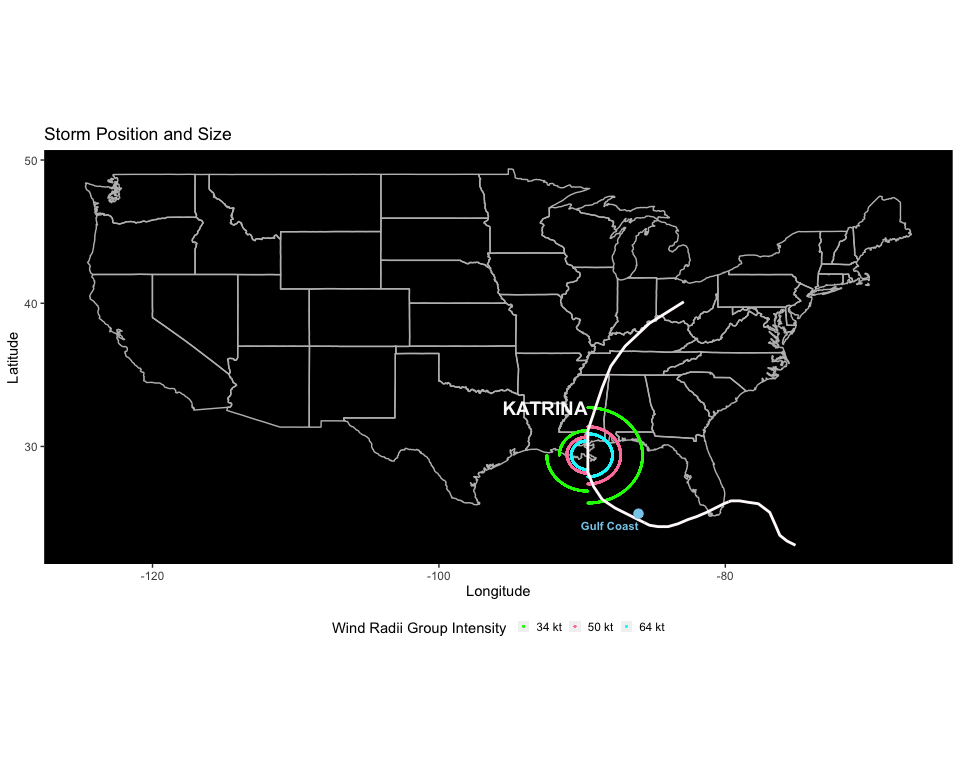

```r
tempi = WHIRL::plot_storm_size_helper(processed_hurdat,
                                        "katrina",
                                        "2005")
pi = WHIRL::plot_storm_size(tempi[1,],tempi[-1,])
pi + ggplot2::geom_point(data=gulf,
                          ggplot2::aes(x = new_lon, y = new_lat),
                          color = "skyblue",
                          size = 3) +
  ggplot2::geom_text(data = gulf,
                         ggplot2::aes(x = new_lon,
                                      y = new_lat,
                                      label = Name),
                     size = 3, vjust = 2, fontface = "bold",
                         hjust = 1, color="skyblue")
```